# Analyzing Forest Fire Data

Forest fires can create ecological problems and endanger human lives and property. Understanding when they occur and what causes them is important for managing them.

The data in this project is associated with [a scientific research paper](http://www3.dsi.uminho.pt/pcortez/fires.pdf) on predicting the occurrence of forest fires in Portugal using modeling techniques.

```r
library(readr)
library(dplyr)
```

```r
library(ggplot2)
library(purrr)
```

```r
forest_fires <- read_csv("forestfires.csv")
head(forest_fires)
```

| X | Y | month | day | FFMC | DMC | DC | ISI | temp | RH | wind | rain | area |
| --- | --- | --- | --- | --- | --- | --- | --- | --- | --- | --- | --- | --- |
| 7 | 5 | mar | fri | 86.2 | 26.2 | 94.3 | 5.1 | 8.2 | 51 | 6.7 | 0.0 | 0 |
| 7 | 4 | oct | tue | 90.6 | 35.4 | 669.1 | 6.7 | 18.0 | 33 | 0.9 | 0.0 | 0 |
| 7 | 4 | oct | sat | 90.6 | 43.7 | 686.9 | 6.7 | 14.6 | 33 | 1.3 | 0.0 | 0 |
| 8 | 6 | mar | fri | 91.7 | 33.3 | 77.5 | 9.0 | 8.3 | 97 | 4.0 | 0.2 | 0 |
| 8 | 6 | mar | sun | 89.3 | 51.3 | 102.2 | 9.6 | 11.4 | 99 | 1.8 | 0.0 | 0 |
| 8 | 6 | aug | sun | 92.3 | 85.3 | 488.0 | 14.7 | 22.2 | 29 | 5.4 | 0.0 | 0 |

Here are descriptions of the variables in the data set and the range of values for each taken from the paper:

- **X**: X-axis spatial coordinate within the Montesinho park map: 1 to 9
- **Y**: Y-axis spatial coordinate within the Montesinho park map: 2 to 9
- **month**: Month of the year: ‘jan’ to ‘dec’
- **day**: Day of the week: ‘mon’ to ‘sun’
- **FFMC**: Fine Fuel Moisture Code index from the FWI system: 18.7 to 96.20
- **DMC**: Duff Moisture Code index from the FWI system: 1.1 to 291.3
- **DC**: Drought Code index from the FWI system: 7.9 to 860.6
- **ISI**: Initial Spread Index from the FWI system: 0.0 to 56.10
- **temp**: Temperature in Celsius degrees: 2.2 to 33.30
- **RH**: Relative humidity in percentage: 15.0 to 100
- **wind**: Wind speed in km/h: 0.40 to 9.40
- **rain**: Outside rain in mm/m2 : 0.0 to 6.4
- **area**: The burned area of the forest (in ha): 0.00 to 1090.84

The acronym FWI stands for [fire weather index](https://en.wikipedia.org/wiki/Forest_fire_weather_index), a method used by scientists to quantify risk factors for forest fires.

There are two variables that have to do with time: month and day. We can ask the questions:

- During which months are forest fires most common?
- On which days of the week are forest fires most common?

#### Fires by Month

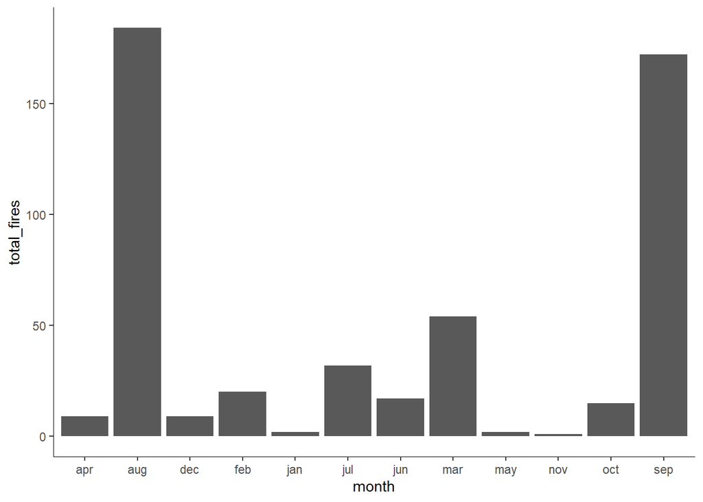

```r
fires_by_month <- forest_fires %>%
  group_by(month) %>%
  summarize(total_fires = n())
ggplot(data = fires_by_month) +
  aes(x = month, y = total_fires) +
  geom_bar(stat = "identity")  +
  theme(panel.background = element_rect(fill = "white"),
        axis.line = element_line(size = 0.25,
                                 colour = "black"))
```

#### Fires by Day of the Week

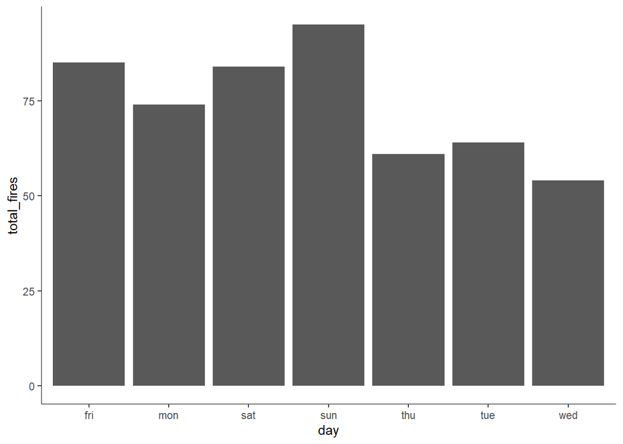

```r
fires_by_DOW <- forest_fires %>%
  group_by(day) %>%
  summarize(total_fires = n())
ggplot(data = fires_by_DOW) +
  aes(x = day, y = total_fires) +
  geom_bar(stat = "identity") +
  theme(panel.background = element_rect(fill = "white"),
        axis.line = element_line(size = 0.25,
                                 colour = "black"))
```

These charts let us see some trends. August and September certainly have the most fires, and Wednesdays seems to have fewer fires than other days of the week.

Changing the order of the months.

```r
forest_fires <- forest_fires %>%
  mutate(month = factor(month, levels = c("jan", "feb", "mar", "apr", "may", "jun", "jul", "aug", "sep", "oct", "nov", "dec")),
         day = factor(day, levels = c("sun", "mon", "tue", "wed", "thu", "fri", "sat")))
```

#### Fires by Month(Reordered)

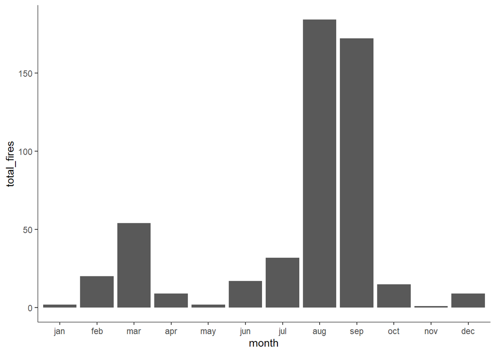

```r
fires_by_month <- forest_fires %>%
  group_by(month) %>%
  summarize(total_fires = n())
ggplot(data = fires_by_month) +
  aes(x = month, y = total_fires) +
  geom_bar(stat = "identity")  +
  theme(panel.background = element_rect(fill = "white"),
        axis.line = element_line(size = 0.25,
                                 colour = "black"))
```

#### Fired by Day of the Week(Reordered)

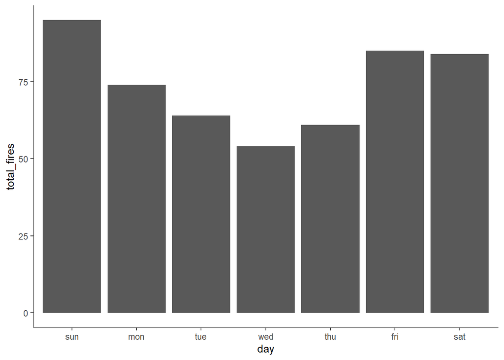

```r
fires_by_DOW <- forest_fires %>%
  group_by(day) %>%
  summarize(total_fires = n())
ggplot(data = fires_by_DOW) +
  aes(x = day, y = total_fires) +
  geom_bar(stat = "identity") +
  theme(panel.background = element_rect(fill = "white"),
        axis.line = element_line(size = 0.25,
                                 colour = "black"))
```

It’s clear that August and September, late summer months in the Northern hemisphere, see more forest fires than other months.

It also looks as though Friday, Saturday, and Sunday have more forest fires than days in the middle of the week.

To explore causes of the temporal patterns of forest fire occurrence the bar charts reveal, we can look more closely at how the variables that relate to forest fires vary by month and by day of the week.

```r
create_boxplots <- function(x, y) {
  ggplot(data = forest_fires) +
    aes_string(x = x, y = y) +
    geom_boxplot() +
    theme(panel.background = element_rect(fill = "white"))
}
x_var_month <- names(forest_fires)[3] ## month
y_var <- names(forest_fires)[5:12]

month_box <- map2(x_var_month, y_var, create_boxplots) ## visualize variables by month
```

#### Fires by Month(Box Plot)

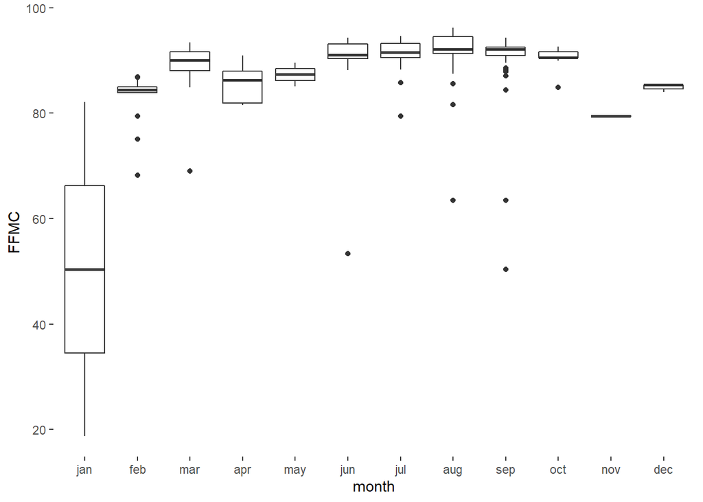

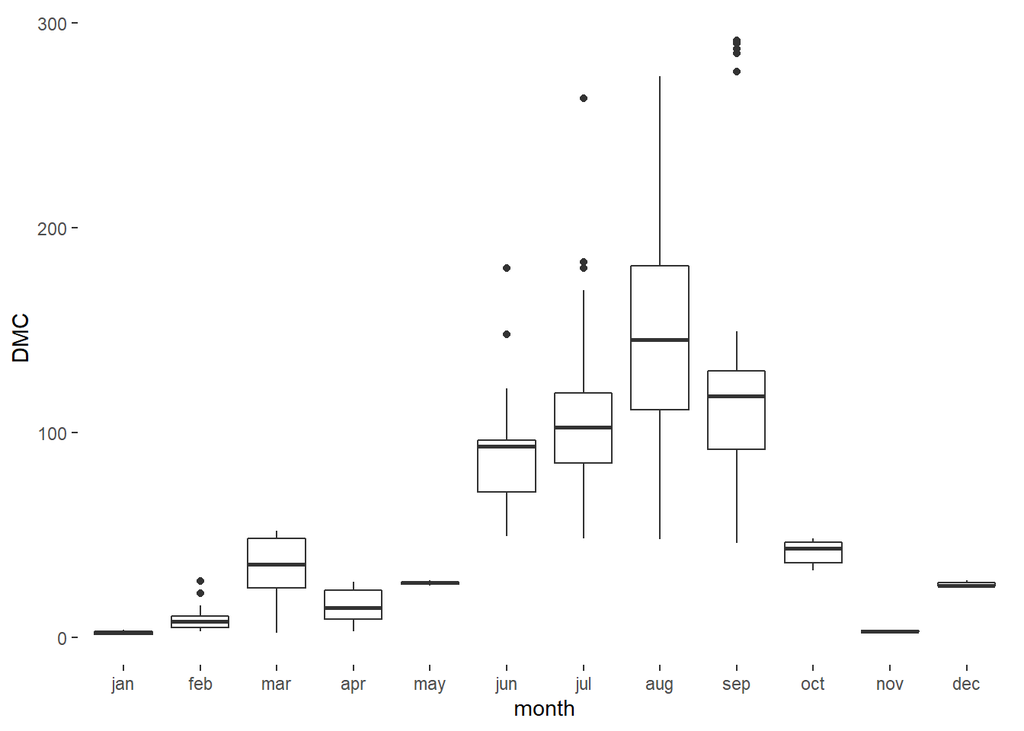

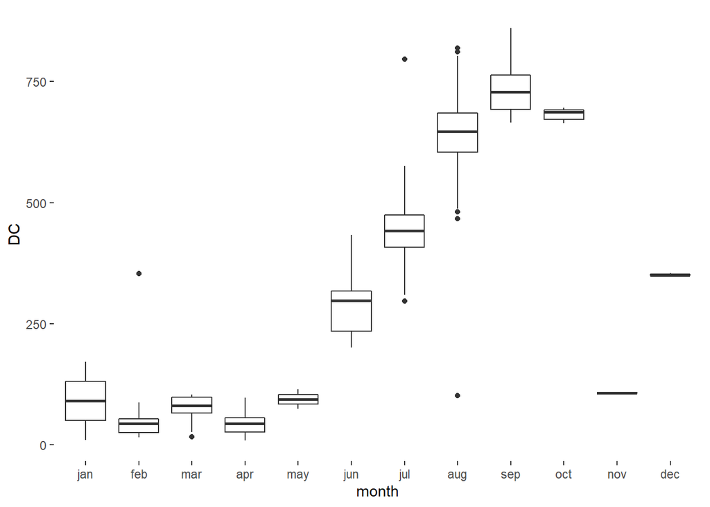

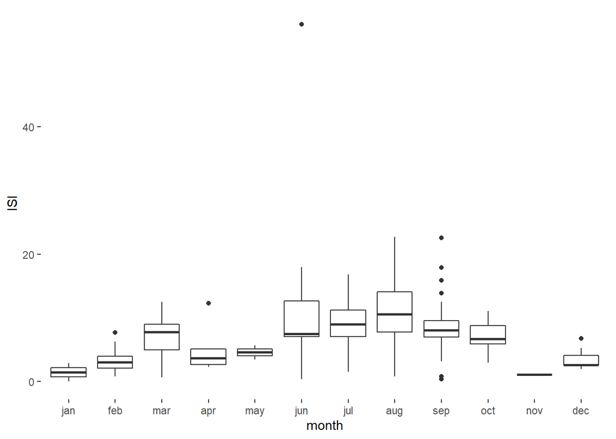

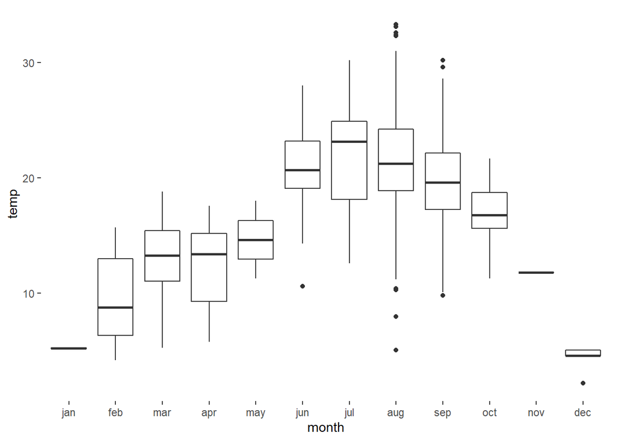

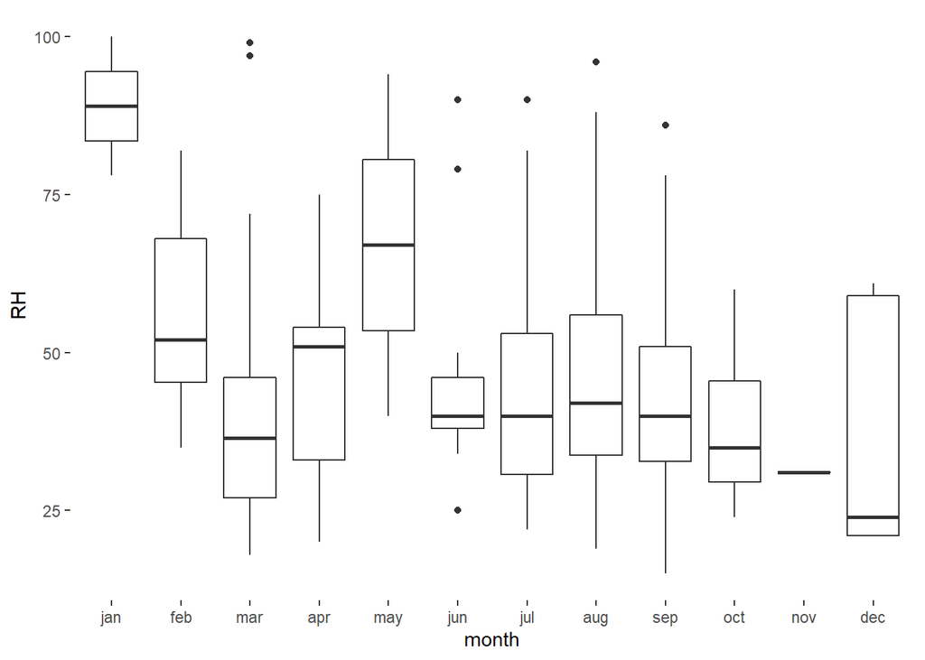

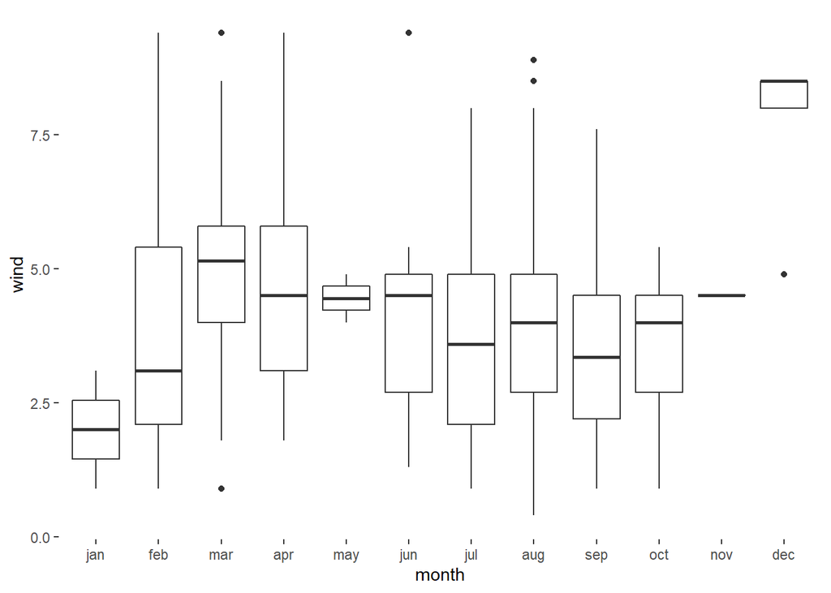

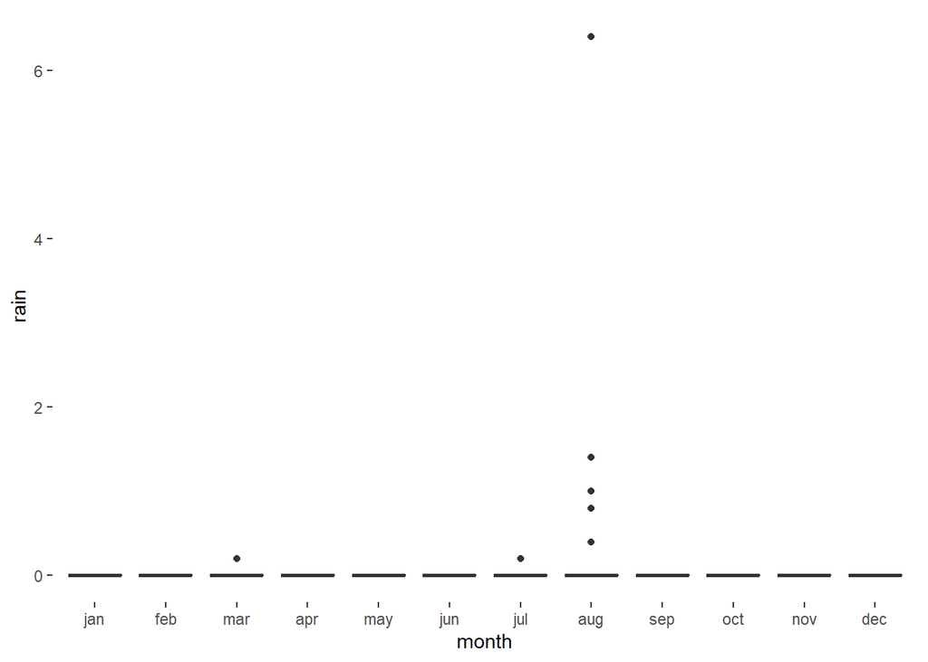

```r
month_box
```

#### Fires by Day of the Week(Box Plot)

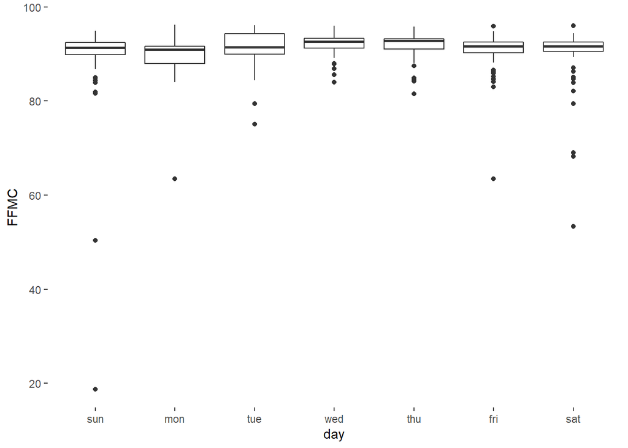

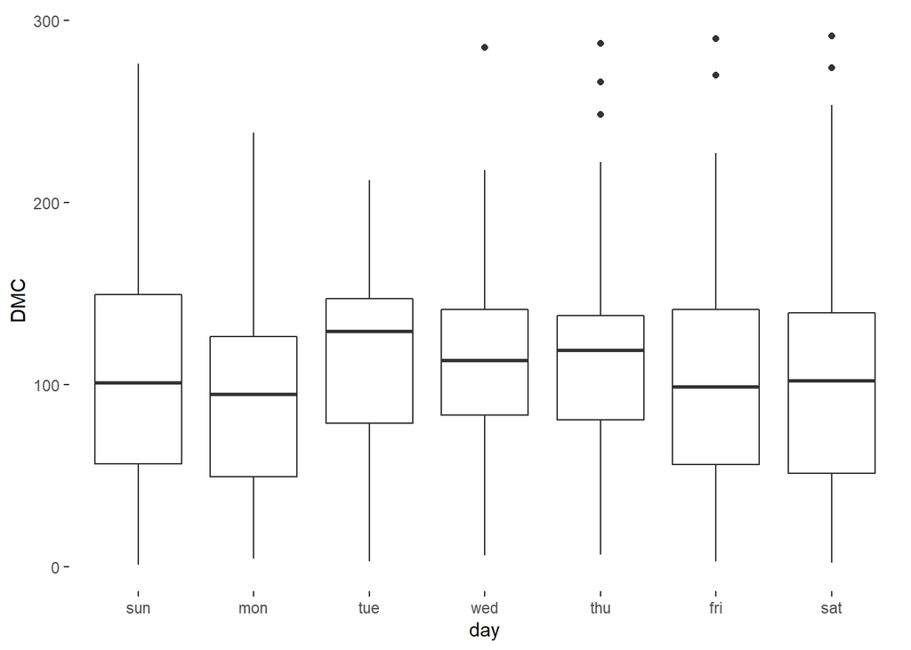

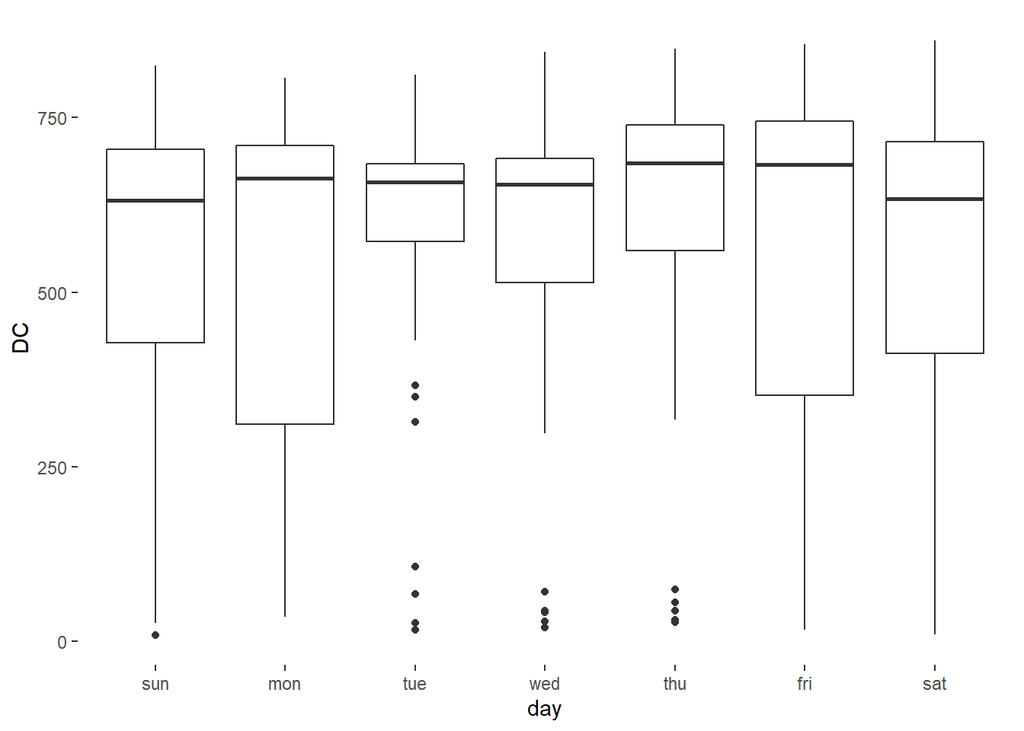

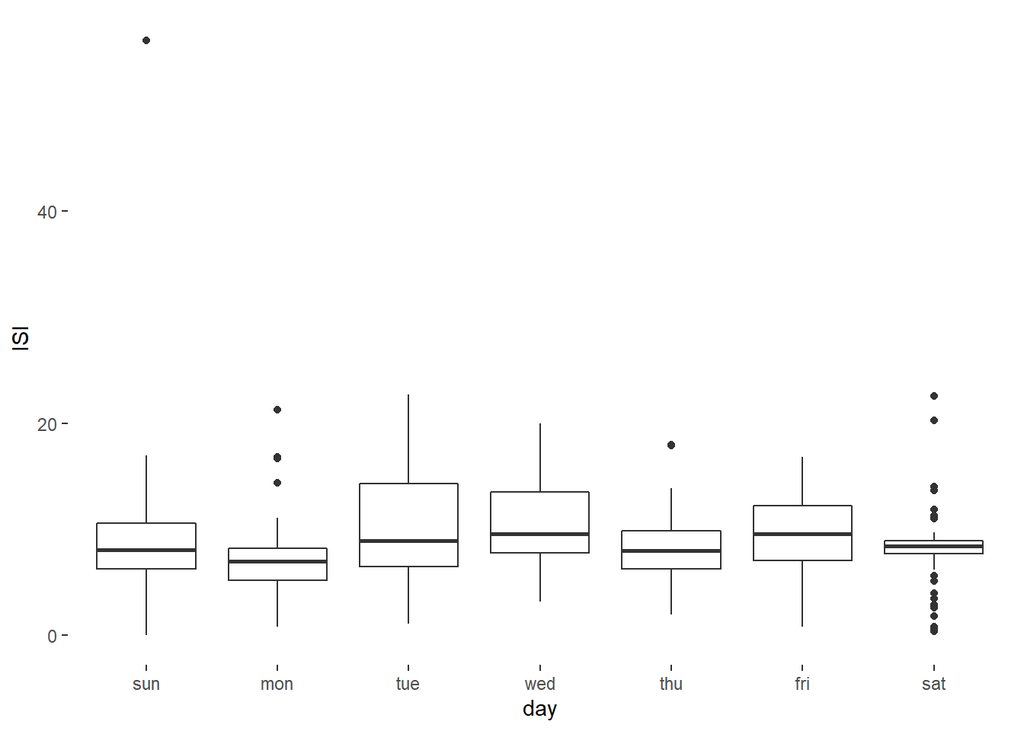

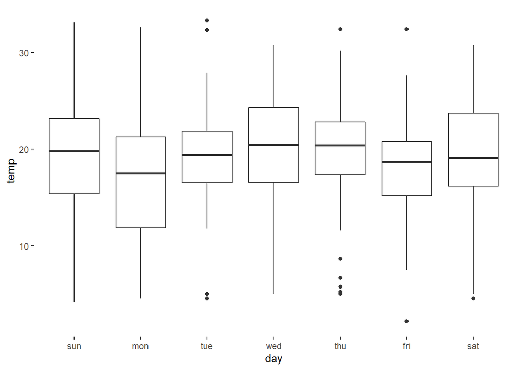

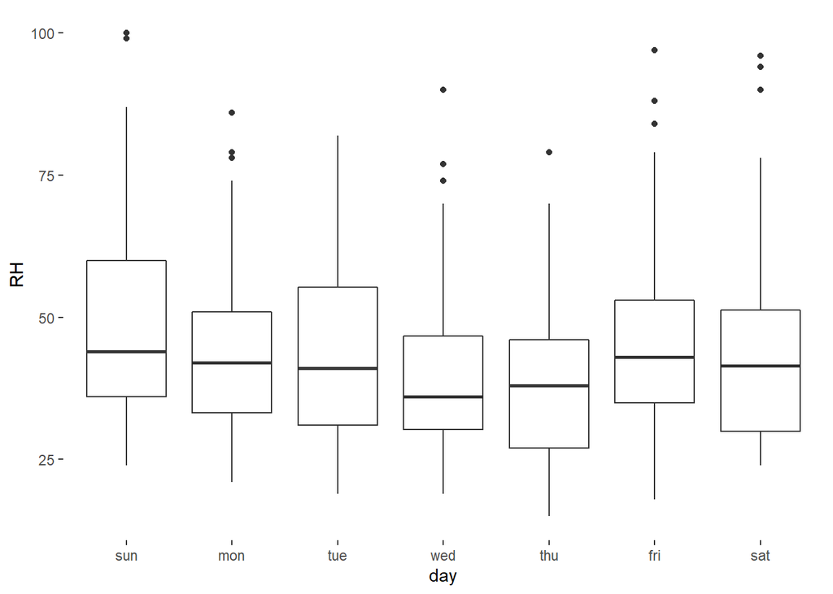

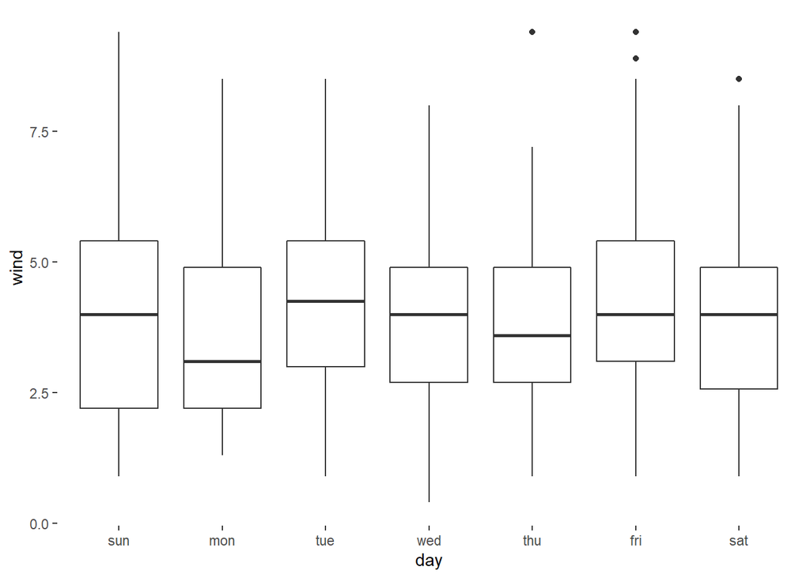

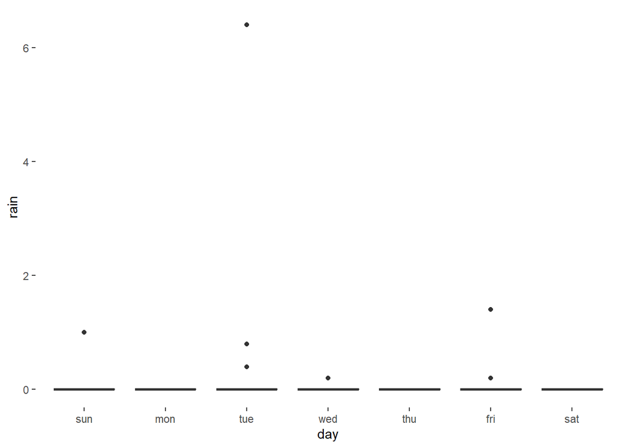

```r
x_var_day <- names(forest_fires)[4] ## day

day_box <- map2(x_var_day, y_var, create_boxplots) ## visualize variables by day

day_box
```

```r
create_scatterplots = function(x, y) {
  ggplot(data = forest_fires) +
    aes_string(x = x, y = y) +
    geom_point() +
    theme(panel.background = element_rect(fill = "white"))
}

x_var_scatter <- names(forest_fires)[5:12]
y_var_scatter <- names(forest_fires)[13]

scatters <- map2(x_var_scatter, y_var_scatter, create_scatterplots)
```

#### Scatter Plots

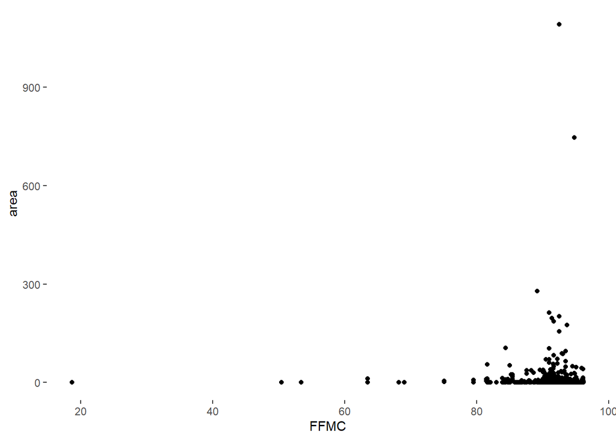

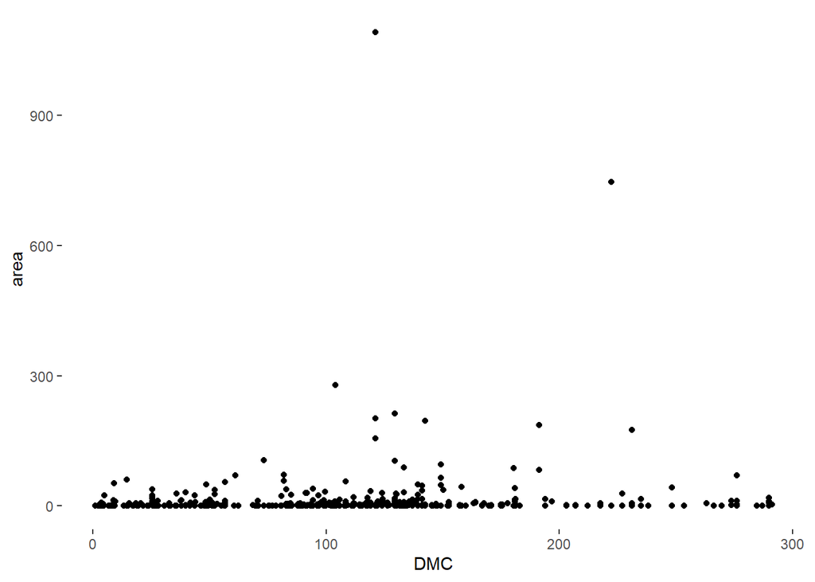

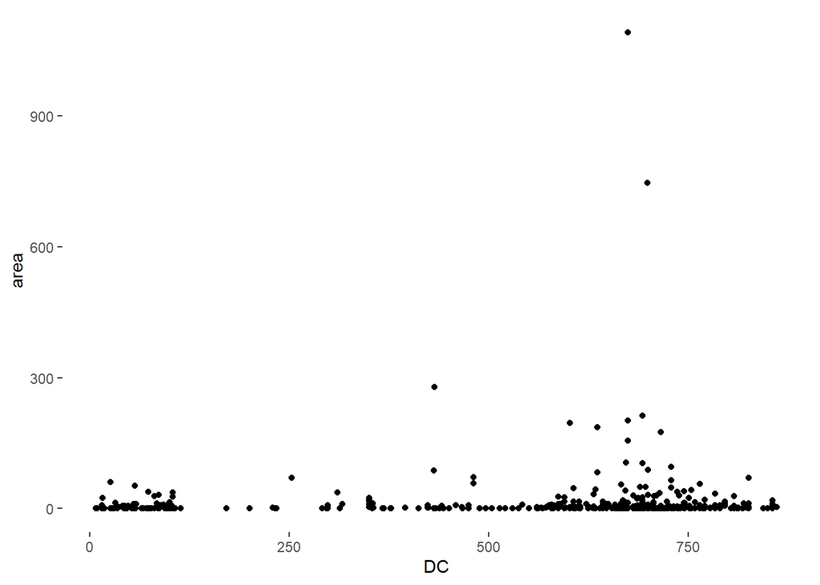

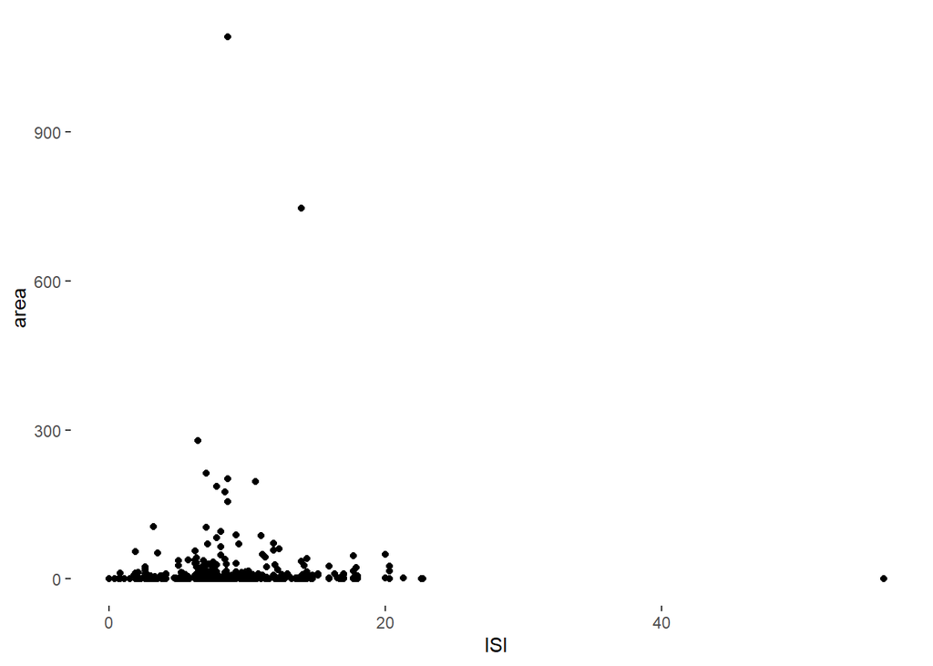

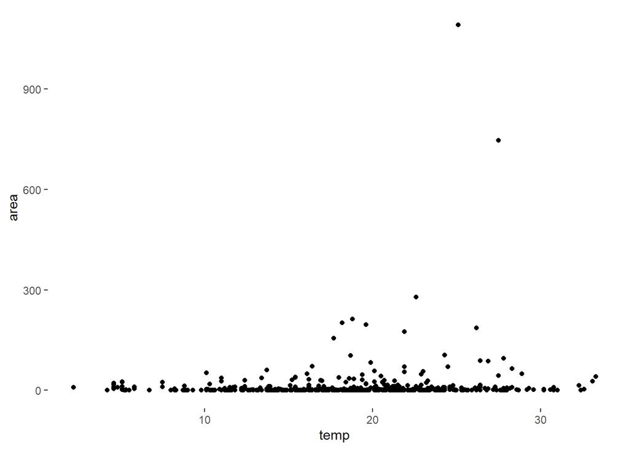

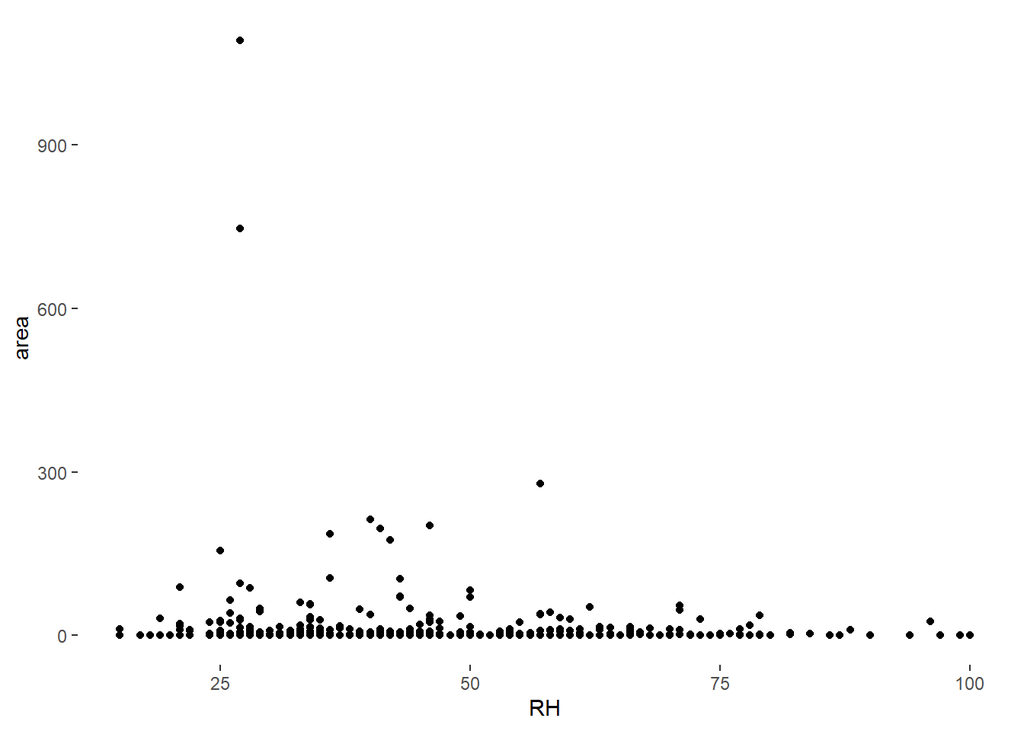

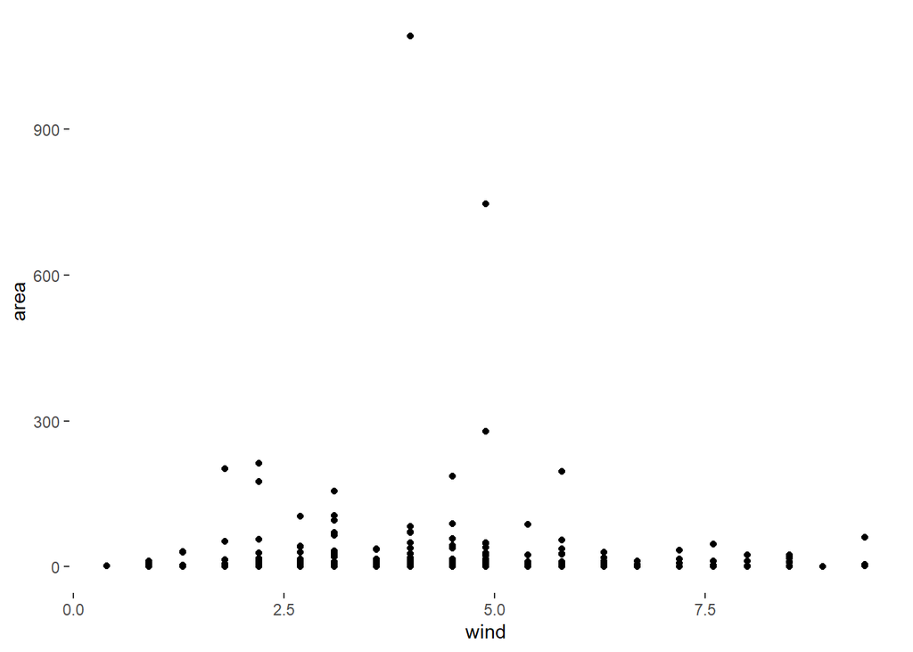

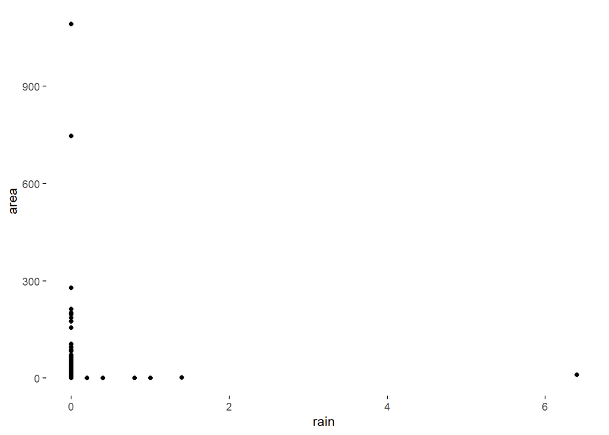

```r
scatters
```

There are a few points representing very large values of area, and many points representing values of area that are zero or close to zero. As a result, most points are clustered around the bottom of the plots.